# A Hands-on Tutorial with Double Machine Learning

Authors

Affiliation

Jonathan Fuhr

University of Tübingen

Dominik Papies

University of Tübingen

Published

May 26, 2023

This notebook accompanies the EMAC workshop tutorial on double/debiased machine learning in the Special Session of the SIG Quantitative Marketing. All code is meant to be replicable. The data for the application can be found in the associated Github repository or under the given link.

## 1 Simulate data to test DML on

This is a very simple simulation example to illustrate the flexibility of DML. We simulate one confounder ($X$) which influences both the treatment $W$ and the outcome $Y$. In the linear data-generating process (DGP), the confounder has a linear influence, in the nonlinear DGP, the influence is quadratic/u-shaped.

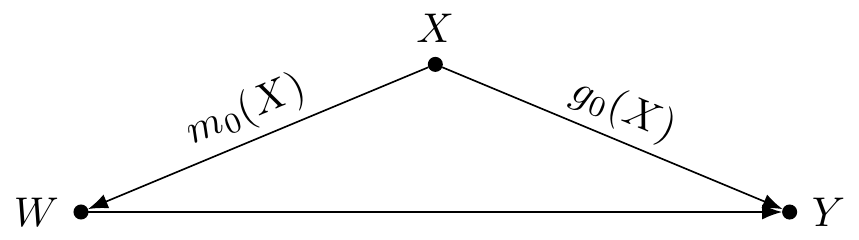

#### Linear DGP

Linear influence of confounders: $m_0(X) = g_0(X) = X$

**R**

```r
library(randomForest); set.seed(314)
n <- 1000
x <- rnorm(n)
w <- x + rnorm(n)      # Treatment in linear DGP
y <- w + x + rnorm(n)  # Outcome in linear DGP
df_lin <- data.frame(y, w, x)
```

**Python**

```python
import numpy as np; import pandas as pd; np.random.seed(314)

n = 1000
x = np.random.normal(size=n)
w = x + np.random.normal(size=n)      # Treatment in linear DGP
y = w + x + np.random.normal(size=n)  # Outcome in linear DGP
df_lin = pd.DataFrame({'y': y, 'w': w, 'x': x})

# Or: import the simulated data from R
df_lin = r.df_lin
```

#### Nonlinear DGP

Nonlinear (u-shaped) influence of confounders: $m_0(X) = g_0(X) = X^2$

**R**

```r
library(randomForest); set.seed(314)
n <- 1000
x <- rnorm(n)
w <- x^2 + rnorm(n)      # Treatment in nonlinear DGP
y <- w + x^2 + rnorm(n)  # Outcome in nonlinear DGP
df_nonlin <- data.frame(y, w, x)
```

**Python**

```python
import numpy as np; import pandas as pd; np.random.seed(314)

n = 1000
x = np.random.normal(size=n)
w = x**2 + np.random.normal(size=n)      # Treatment in nonlinear DGP
y = w + x**2 + np.random.normal(size=n)  # Outcome in nonlinear DGP
df_nonlin = pd.DataFrame({'y': y, 'w': w, 'x': x})

# Or: import the simulated data from R (to use the identical data)
df_nonlin = r.df_nonlin
```

## 2 Manual implementation of DML

Here, we implement a very rudimentary version of the DML algorithm manually. It consists of two functions. The first function does the machine learning and the estimation; the second one implements the cross-fitting and repeatedly calls the first function for each of the folds.

#### Own implementation: 1. Doing DML once

In this function, we use random forests as the machine learning algorithm, but we could use any other predictive method as well.

**R**

```r
dml_once_rf <- function(dataset, idx1, idx2) {  # indices come from second function
  # Predicting treatment from the controls, using first part of the data
  rf1 <- randomForest(formula = w ~ . - y, data = dataset[idx1, ], ntree = 200)

  # Predicting outcome from the controls, using first part of the data
  rf2 <- randomForest(formula = y ~ . - w, data = dataset[idx1, ], ntree = 200)

  # Make predictions for treatment and outcome with trained model, using second half of the data
  W_hat <- predict(rf1, newdata = dataset[idx2, ])
  Y_hat <- predict(rf2, newdata = dataset[idx2, ])

  # Compute residuals for treatment and outcome
  W_resid <- dataset[idx2, "w"] - W_hat
  Y_resid <- dataset[idx2, "y"] - Y_hat

  # Regress residual of outcome on residual of treatment, obtain coefficient for treatment residual
  beta_w <- coef(lm(Y_resid ~ 0 + W_resid))
  return(beta_w)
}
```

**Python**

```python
from sklearn.ensemble import RandomForestRegressor
from sklearn.linear_model import LinearRegression
def dml_once_rf(dataset, idx1, idx2):
  """Run DML once (for a single fold in the cross validation)."""

  # Select covariates (everything but w and y)
  covariates = dataset.drop(columns=['w', 'y'])

  # Select w and y
  w = dataset.w
  y = dataset.y

  # Predicting treatment from the controls, using first part of the data
  rf1 = (RandomForestRegressor(n_estimators=200)
         .fit(X=covariates.iloc[idx1, :], y=w.iloc[idx1]))

  # Predicting outcome from the controls, using first part of the data
  rf2 = (RandomForestRegressor(n_estimators=200)
         .fit(X=covariates.iloc[idx1, :], y=y.iloc[idx1]))

  # Make predictions for treatment and outcome with trained model,
  # using second half of the data
  W_hat = rf1.predict(covariates.iloc[idx2, :])
  Y_hat = rf2.predict(covariates.iloc[idx2, :])

  # Compute residuals for treatment and outcome
  W_resid = w.iloc[idx2] - W_hat
  Y_resid = y.iloc[idx2] - Y_hat

  # Regress residual of outcome on residual of treatment, obtain coefficient for treatment residual
  beta_w = (LinearRegression(fit_intercept=False)
            .fit(X=W_resid.values.reshape(-1, 1), y=Y_resid.values.reshape(-1, 1))
            .coef_[0,0])

  return beta_w
```

#### Own implementation: 2. Cross-fitting

**R**

```r
dml_cross_rf <- function(dataset, K = 5) {
  # Generate indices for K folds
  idx_k <- vector(mode = "list", length = K)
  idx <- 1:nrow(dataset)
  for (k in 1:(K - 1)) { # draw indices for each split randomly into a list
    idx_k[[k]] <- sample(idx, 1/K * nrow(dataset))
    idx <- setdiff(idx, idx_k[[k]])}
  idx_k[[K]] <- idx

  beta <- numeric(K)  # Empty vector to store the coefficients
  # Apply the dml_once() function for each fold: ML on larger, estimation on smaller sample
  for (k in 1:K) {
    # Split sample in two parts
    idx2 <- idx_k[[k]]
    idx1 <- setdiff(1:nrow(dataset), idx2)

    # Run dml_once()
    beta[k] <- dml_once_rf(dataset, idx1, idx2)
    }
  # Average the resulting coefficients
  return(mean(beta))
}
```

**Python**

```python
def dml_cross_rf(dataset, K = 5):
  """Run DML K times for cross validation."""

  # Get number of observations
  n_obs = dataset.shape[0]

  # Generate indices for K folds
  idx_k = []
  idx = np.arange(n_obs)
  for k in range(K - 1):  # Draw indices for each split randomly into a list
    idx_k.append(np.random.choice(idx, n_obs//K, replace=False))
    idx = np.setdiff1d(idx, idx_k[k], assume_unique=True)
  # For last fold
  idx_k.append(idx)

  beta = []  # Empty list to store the coefficients
  # Apply the dml_once() function for each fold:
  # ML on larger, estimation on smaller sample
  for k in range(K):
    # Split sample in two parts
    idx2 = idx_k[k]
    idx1 = np.concatenate(idx_k[:k] + idx_k[k+1:])

    # Run dml_once()
    beta.append(dml_once_rf(dataset, idx1, idx2))

  # Average the resulting coefficients
  return np.mean(beta)
```

#### Application to simulated data

Here, we apply the functions to our simple simulated data.

**R**

###### Linear DGP

```r
coef(lm(formula = y ~ w + x, data = df_lin))[["w"]]  # Standard linear regression
```

```
[1] 0.9989102
```

```r
dml_cross_rf(data = df_lin)     # DML with random forests
```

```
[1] 0.9792316
```

In the linear DGP, the linear regression is the ideal method (since it uses the correct specification), so it recovers the true effect of 1 almost perfectly. However, DML with random forests is also able to learn the linear functional form from the data and gets very close to the true effect.

###### Nonlinear DGP

```r
coef(lm(formula = y ~ w + x, data = df_nonlin))[["w"]]  # Standard linear regression
```

```
[1] 1.624993
```

```r
dml_cross_rf(data = df_nonlin)     # DML with random forests
```

```
[1] 1.043148
```

In the nonlinear DGP, the linear regression is misspecified, so it incurs a severe bias. Contrary to that, DML with random forests recovers the true effect almost perfectly again, since it was able to learn the nonlinear functional form from the data.

**Python**

```python
# "Shorter function for the linear regression
def linreg_comp(dataset):
  beta_w = (
    LinearRegression(fit_intercept=True)
    .fit(X=dataset.drop(columns='y'), y=dataset.y)
    .coef_[0] # w is first feature
  )
  return beta_w
```

###### Linear DGP

```python
# Standard linear regression
linreg_comp(df_lin)
```

```
0.9989101911339364
```

```python
# DML with random forests
dml_cross_rf(dataset = df_lin)
```

```
1.0041580112839859
```

In the linear DGP, the linear regression is the ideal method (since it uses the correct specification), so it recovers the true effect of 1 almost perfectly. However, DML with random forests is also able to learn the linear functional form from the data and gets very close to the true effect.

###### Nonlinear DGP

```python
# Standard linear regression
linreg_comp(df_nonlin)
```

```
1.6249925610209195
```

```python
# DML with random forests
dml_cross_rf(dataset = df_nonlin)
```

```
0.9919640790681756
```

In the nonlinear DGP, the linear regression is misspecified, so it incurs a severe bias. Contrary to that, DML with random forests recovers the true effect almost perfectly again, since it was able to learn the nonlinear functional form from the data.

## 3 DML implementation with {DoubleML} package

Here we show how to use the object-oriented implementation of DML in the {DoubleML} package by Bach, Chernozhukov, Kurz, et al. (2023).

#### 1. Construct data object

**R**

```r
library(DoubleML)
dml_data <- DoubleMLData$new(df_nonlin, y_col = "y", d_cols = "w", x_cols = c("x"))
```

**Python**

```python
from doubleml import DoubleMLData
dml_data = DoubleMLData(df_nonlin, y_col = "y", d_cols = "w", x_cols = ["x"])
```

#### 2. Initialize ML models (choose any, here random forests)

**R**

```r
library(mlr3); library(mlr3learners)
ml_l_rf <- lrn("regr.ranger", num.trees = 200)  # outcome model
ml_m_rf <- lrn("regr.ranger", num.trees = 200)  # treatment model
```

**Python**

```python
from sklearn.ensemble import RandomForestRegressor
ml_l_rf = RandomForestRegressor(n_estimators = 200)  # outcome model
ml_m_rf = RandomForestRegressor(n_estimators = 200)  # treatment model
```

#### 3. Initialize DoubleML object

**R**

```r
dml_plr_rf <- DoubleMLPLR$new(dml_data, ml_l = ml_l_rf, ml_m = ml_m_rf)
```

**Python**

```python
from doubleml import DoubleMLPLR
dml_plr_rf = DoubleMLPLR(dml_data, ml_l = ml_l_rf, ml_m = ml_m_rf)
```

#### 4. Estimate the model

**R**

```r
dml_plr_rf$fit()
```

**Python**

```python
dml_plr_rf.fit()
```

#### 5. Show the estimates

**R**

```r
dml_plr_rf$coef
```

```
       w
1.003014
```

```r
dml_plr_rf$summary()
```

```
Estimates and significance testing of the effect of target variables
  Estimate. Std. Error t value Pr(>|t|)
w   1.00301    0.03101   32.34   <2e-16 ***
---
Signif. codes:  0 '***' 0.001 '**' 0.01 '*' 0.05 '.' 0.1 ' ' 1
```

**Python**

```python
dml_plr_rf.coef
```

```
array([1.02370421])
```

```python
dml_plr_rf.summary
```

```
       coef  std err          t          P>|t|     2.5 %   97.5 %
w  1.023704  0.03208  31.910686  1.898025e-223  0.960828  1.08658
```

## 4 DML application

#### The data

In this section, we work with a real-world dataset from Leeflang et al. (2015) to illustrate the application of DML. Note that this is a toy example, we do not claim causal identification in this setting. Also, while the data actually originates from a time series of observations, we will pretend and treat it as a cross-section in this toy illustration to make it suitable for DML. The statistical guarantees of DML are only proven for the cross-sectional setting by Chernozhukov et al. (2018).

As Leeflang et al. (2015) describe, the data deals with chocolate sales by the Dutch chocolate company Verhouten. The supermarket scanner data contains information on sales, prices, and promotion of Verhouten chocolate, plus prices and promotional activities for competitor brands. Also, there are variables recording the temperature and whether an observation is during December or Easter.

#### Data import

**R**

```r
library(dplyr)
# data source: http://www.modelingmarkets.com/chocolate_dataset.csv
dchoc <- read.csv("data/chocolate_dataset.csv") %>%
  mutate(log_sales = log(sales),    # transforming sales to log(sales)
         log_price1 = log(price1))  # transforming price of Verhouten to log(price1)

glimpse(dchoc)
```

```
Rows: 68
Columns: 21
$ sales      <dbl> 66.42610, 85.72856, 89.52277, 98.77386, 102.88100, 105.8124…
$ price1     <dbl> 1.509557, 1.509594, 1.510057, 1.507783, 1.506977, 1.507235,…
$ price2     <dbl> 1.559941, 1.558169, 1.553499, 1.556005, 1.561368, 1.256176,…
$ price3     <dbl> 1.748575, 1.376562, 1.403592, 1.478236, 1.583986, 1.654707,…
$ price4     <dbl> 1.277969, 1.355054, 1.488910, 1.727150, 1.797017, 1.882738,…
$ feature1   <dbl> 0.00, 0.00, 0.00, 0.10, 0.20, 0.00, 0.44, 0.24, 0.08, 0.02,…
$ feature2   <dbl> 0.00, 0.00, 0.00, 0.00, 0.00, 0.00, 0.29, 0.03, 0.03, 0.00,…
$ feature3   <dbl> 0.00, 0.00, 0.00, 0.29, 0.08, 0.00, 0.00, 0.00, 0.00, 0.00,…
$ feature4   <dbl> 0.35, 0.54, 0.14, 0.05, 0.00, 0.02, 0.00, 0.00, 0.02, 0.02,…
$ display1   <dbl> 0.00, 0.00, 0.00, 0.00, 0.00, 0.00, 0.00, 0.00, 0.00, 0.00,…
$ display2   <dbl> 0, 0, 0, 0, 0, 0, 0, 0, 0, 0, 0, 0, 0, 0, 0, 0, 0, 0, 0, 0,…
$ display3   <dbl> 0.00, 0.82, 0.85, 0.00, 0.00, 0.00, 0.00, 0.00, 0.00, 0.00,…
$ display4   <dbl> 0.00, 0.00, 0.00, 0.00, 0.00, 0.00, 0.00, 0.00, 0.00, 0.00,…
$ fand1      <dbl> 0, 0, 0, 0, 0, 0, 0, 0, 0, 0, 0, 0, 0, 0, 0, 0, 0, 0, 0, 0,…
$ fand3      <dbl> 0.00, 0.47, 0.86, 0.00, 0.00, 0.00, 0.00, 0.00, 0.00, 0.00,…
$ fand4      <dbl> 0.00, 0.00, 0.00, 0.00, 0.00, 0.00, 0.00, 0.00, 0.00, 0.00,…
$ temp       <int> 2, -1, 3, 2, 5, 3, 1, 2, 4, 7, 5, 6, 9, 8, 8, 13, 12, 10, 1…
$ december   <int> 1, 0, 0, 0, 0, 0, 0, 0, 0, 0, 0, 0, 0, 0, 0, 0, 0, 0, 0, 0,…
$ easter     <int> 0, 0, 0, 0, 0, 0, 0, 0, 0, 0, 0, 0, 0, 0, 0, 0, 0, 0, 0, 0,…
$ log_sales  <dbl> 4.196090, 4.451186, 4.494493, 4.592833, 4.633573, 4.661668,…
$ log_price1 <dbl> 0.41181597, 0.41184043, 0.41214721, 0.41064019, 0.41010533,…
```

**Python**

```python
import pandas as pd
import numpy as np

# data source: http://www.modelingmarkets.com/chocolate_dataset.csv
dchoc = pd.read_csv('data/chocolate_dataset.csv')
dchoc['log_sales'] = np.log(dchoc['sales'])
dchoc['log_price1'] = np.log(dchoc['price1'])

dchoc.columns
```

```
Index(['sales', 'price1', 'price2', 'price3', 'price4', 'feature1', 'feature2',
       'feature3', 'feature4', 'display1', 'display2', 'display3', 'display4',
       'fand1', 'fand3', 'fand4', 'temp', 'december', 'easter', 'log_sales',
       'log_price1'],
      dtype='object')
```

```python
print(dchoc.head())
```

```
        sales    price1    price2  ...  easter  log_sales  log_price1
0   66.426097  1.509557  1.559941  ...       0   4.196090    0.411816
1   85.728558  1.509594  1.558169  ...       0   4.451186    0.411840
2   89.522769  1.510057  1.553499  ...       0   4.494493    0.412147
3   98.773861  1.507783  1.556005  ...       0   4.592833    0.410640
4  102.881002  1.506977  1.561368  ...       0   4.633573    0.410105

[5 rows x 21 columns]
```

#### The goal and one naive approach

In this example, we want to estimate the price elasticity of demand for the Verhouten chocolate, i.e., the effect of `log_price1` on `log_sales`. A naive simple linear regression only regresses sales on price:

**R**

```r
summary(lm(log_sales ~ log_price1, data = dchoc))$coef["log_price1", ]
```

```
     Estimate    Std. Error       t value      Pr(>|t|)
-3.937954e+00  2.153666e-01 -1.828489e+01  1.560591e-27
```

**Python**

```python
import statsmodels.api as sm
model = sm.formula.ols(formula='log_sales ~ log_price1', data=dchoc)
results = model.fit()
print(results.params['log_price1'])
```

```
-3.9379538134723466
```

#### One traditional approach

Since we would expect that the other covariates (advertising, competitor prices, temperature, etc.) can influence both the price and the sales, we typically want to adjust for them. Traditionally, we could do this with a linear regression, where we include these other variables as control variables.

**R**

```r
# Create a formula for the regression and other future models:
form_full <- log_sales ~ log_price1 + price2 + price3 + price4 + feature1 +
  feature2 + feature3 + feature4 + display1 + display2 + display3 +
  display4 + fand1 + fand3 + fand4 + temp + december + easter

summary(lm(form_full, data = dchoc))$coef["log_price1", ]
```

```
     Estimate    Std. Error       t value      Pr(>|t|)
-3.852695e+00  3.205155e-01 -1.202031e+01  3.176756e-16
```

**Python**

```python
import statsmodels.api as sm
model = sm.formula.ols(formula='''log_sales ~ log_price1 + price2 + price3 +
                                  price4 + feature1 + feature2 + feature3 +
                                  feature4 + display1 + display2 + display3 +
                                  display4 + fand1 + fand3 + fand4 + temp +
                                  december + easter''',
                       data=dchoc)
results = model.fit()
print(results.params['log_price1'])
```

```
-3.8526950229139696
```

Here, the estimated effect is absolutely smaller than in the naive regression, but not by much. While in this application the linear adjustment does not make a big difference, it probably will in various other applications.

#### Estimation with DML

With the linear regression, we make the assumption that the covariates influence the sales and/or the price with the specified (here linear) functional form. By using DML, we can relax this assumption and let the algorithm learn the functional form of the confounding from the data.

In the hidden/folded chunk, we write a more elaborate R version of the DML algorithm with random forests, which returns the standard error and the predictive accuracy in the first stage in addition to the coefficient estimate.

**More elaborate DML version with random forests**

```r
library(randomForest); library(dplyr)

dml_once_rf <- function(dataset, idx1, idx2, num_trees,
                        outcome = outcome, treatment = treatment) {

  # Estimate each submodel separately, on its own half of the data
  rf1 <- randomForest(
    formula = as.formula(paste0(treatment, " ~ . - ", outcome)),
    data = dataset[idx1, ],
    ntree = num_trees,
    type = "regression",
    seed = 123
  )

  rf2 <- randomForest(
    formula = as.formula(paste0(outcome, " ~ . - ", treatment)),
    data = dataset[idx1, ],
    ntree = num_trees,
    type = "regression",
    seed = 123
  )

  # Predict and residualize
  EWhat <- predict(rf1, newdata = dataset[idx2, ]) %>% as.numeric()
  EYhat <- predict(rf2, newdata = dataset[idx2, ]) %>% as.numeric()

  W_resid <- dataset[idx2, treatment] - EWhat
  Y_resid <- dataset[idx2, outcome] - EYhat

  # Linear regression
  betaw <- lm(Y_resid ~ 0 + W_resid) %>% coef

  # MSEs
  mse_w <- mean((EWhat - dataset[idx2, treatment])^2)
  mse_y <- mean((EYhat - dataset[idx2, outcome])^2)

  # Stuff for variance estimator
  score_a <- mean(-(W_resid)^2)
  score_full <- mean((-(W_resid)^2 * betaw + Y_resid * W_resid)^2)

  df_once <- data.frame(betaw, mse_w, mse_y, score_a, score_full)
  return(df_once)
}

double_ml_rf <- function(dataset, formula, num_trees = 200, K = 5,
                         outcome = "y", treatment = "w") {

  cov_matrix <- model.matrix(formula, dataset) %>%
    subset(select = !(colnames(.) %in% c("(Intercept)", treatment)))

  dataset <- data.frame(dataset[, outcome],
                        dataset[, treatment],
                        cov_matrix)
  names(dataset) <- c(outcome, treatment, colnames(cov_matrix))

  # Generate indices for K folds
  idx_k <- vector(mode = "list", length = K)
  idx <- 1:nrow(dataset)
  for (k in 1:(K - 1)) { # draw indices for each split randomly into a list
    idx_k[[k]] <- sample(idx, 1/K * nrow(dataset))
    idx <- setdiff(idx, idx_k[[k]])}
  idx_k[[K]] <- idx

  df_cross <- data.frame(beta = rep(NA, K),
                         mse_w = rep(NA, K),
                         mse_y = rep(NA, K),
                         score_a = rep(NA, K),
                         score_full = rep(NA, K))


  # Apply the function for each fold, estimate nuisance parameters on larger
  # sample, estimate parameter of interest on rest
  for (k in 1:K) {
    # Splits sample
    idx2 <- idx_k[[k]]
    idx1 <- setdiff(1:nrow(dataset), idx2)

    df_cross[k, ] <- dml_once_rf(dataset, idx1, idx2, num_trees,
                                 outcome = outcome, treatment = treatment)
  }

  # Average the resulting coefficients
  means_cross <- colMeans(df_cross)

  # Compute standard errors
  J_hat <- means_cross["score_a"]
  sigma_hat <- unname(sqrt(1/J_hat^2 * means_cross["score_full"]))/sqrt(nrow(dataset))

  resfull <- c(means_cross[1], se = sigma_hat, means_cross[2:3])
  return(resfull)
}
```

Then, we apply this DML function to the Verhouten data example:

```r
set.seed(314)
double_ml_rf(dataset = dchoc, formula = form_full,
             outcome = "log_sales", treatment = "log_price1", K = 7)
```

```
        beta           se        mse_w        mse_y
-3.473462165  0.224939668  0.008029504  0.129608516
```

We get an estimate that is absolutely smaller than the one from the linear regression. We could consider this plausible, since adjusting also lead to an absolutely smaller price elasticity compared with to adjusting at all.

We might want to compare this estimate to ones from DML with other predictive methods. For example, here we implement DML with a linear regression as “machine learning” method and use it for the same task.

**More elaborate DML version with linear regression**

```r
dml_once_lm <- function(dataset, idx1, idx2,
                        outcome = outcome, treatment = treatment) {

  # Estimate each submodel separately, on its own half of the data
  lm1 <- lm(as.formula(paste0(treatment, " ~ . - ", outcome)),
            data = dataset[idx1, ])
  lm2 <- lm(as.formula(paste0(outcome, " ~ . - ", treatment)),
            data = dataset[idx1, ])

  # Predict and residualize
  EWhat <- predict(lm1, newdata = dataset[idx2, ]) %>% as.numeric()
  EYhat <- predict(lm2, newdata = dataset[idx2, ]) %>% as.numeric()

  W_resid <- dataset[idx2, treatment] - EWhat
  Y_resid <- dataset[idx2, outcome] - EYhat

  # Linear regression
  betaw <- lm(Y_resid ~ 0 + W_resid) %>% coef

  # MSEs
  mse_w <- mean((EWhat - dataset[idx2, treatment])^2)
  mse_y <- mean((EYhat - dataset[idx2, outcome])^2)

  # Stuff for variance estimator
  score_a <- mean(-(W_resid)^2)
  score_full <- mean((-(W_resid)^2 * betaw + Y_resid * W_resid)^2)

  df_once <- data.frame(betaw, mse_w, mse_y, score_a, score_full)
  return(df_once)
}

double_ml_lm <- function(dataset, formula, K = 5,
                         outcome = "y", treatment = "w") {

  cov_matrix <- model.matrix(formula, dataset) %>%
    subset(select = !(colnames(.) %in% c("(Intercept)", treatment)))

  dataset <- data.frame(dataset[, outcome],
                        dataset[, treatment],
                        cov_matrix)
  names(dataset) <- c(outcome, treatment, colnames(cov_matrix))

  # Generate indices for K folds
  idx_k <- vector(mode = "list", length = K)
  idx <- 1:nrow(dataset)
  for (k in 1:(K - 1)) { # draw indices for each split randomly into a list
    idx_k[[k]] <- sample(idx, 1/K * nrow(dataset))
    idx <- setdiff(idx, idx_k[[k]])}
  idx_k[[K]] <- idx

  df_cross <- data.frame(beta = rep(NA, K),
                         mse_w = rep(NA, K),
                         mse_y = rep(NA, K),
                         score_a = rep(NA, K),
                         score_full = rep(NA, K))


  # Apply the function for each fold, estimate nuisance parameters on larger
  # sample, estimate parameter of interest on rest
  for (k in 1:K) {
    # Splits sample
    idx2 <- idx_k[[k]]
    idx1 <- setdiff(1:nrow(dataset), idx2)

    df_cross[k, ] <- dml_once_lm(dataset, idx1, idx2,
                                 outcome = outcome, treatment = treatment)
  }

  # Average the resulting coefficients
  means_cross <- colMeans(df_cross)

  # Compute standard errors
  J_hat <- means_cross["score_a"]
  sigma_hat <- unname(sqrt(1/J_hat^2 * means_cross["score_full"]))/sqrt(nrow(dataset))

  resfull <- c(means_cross[1], se = sigma_hat, means_cross[2:3])
  return(resfull)
}
```

```r
set.seed(314)
double_ml_lm(dataset = dchoc, formula = form_full,
             outcome = "log_sales", treatment = "log_price1", K = 7)
```

```
      beta         se      mse_w      mse_y
-2.4886148  0.1673306  0.0109083  0.1746908
```

Surprisingly, this estimate is (absolutely) even smaller and much smaller than our standard linear regression. This is just an artifact of treating this data as cross-sectional. In non-toy examples, the estimate should be very similar to the one from the linear regression.

Nevertheless, we can use this example to illustrate two points:

1. We can use the predictive accuracy of the first stage (`mse_w` & `mse_y`) to decide which of the two DML models (with random forests or with a linear regression) to trust most. If our causal identification argument holds, the one with the higher predictive accuracy (smaller MSE) should also deliver more accurate coefficient estimates. In this example, DML with random forests is far superior in predicting the price and the sales in the first stage.
2. If we repeat the estimation with different or no random seeds, we will get very different estimates each time. This is because the random splitting in the first step impacts the estimation results in samples as small as ours. To make the results more robust to this randomness, Chernozhukov et al. (2018) propose repeating the estimator $S$ times and reporting the median, which we do in the following.

First, we do the algorithm three times with only one repetition.

```r
set.seed(12)
double_ml_rf(dchoc, form_full, outcome = "log_sales",
             treatment = "log_price1", K = 7)
```

```
        beta           se        mse_w        mse_y
-3.130125418  0.134088341  0.009297124  0.160322797
```

```r
double_ml_rf(dchoc, form_full, outcome = "log_sales",
             treatment = "log_price1", K = 7)
```

```
        beta           se        mse_w        mse_y
-3.438799520  0.167773070  0.009186392  0.152462506
```

```r
double_ml_rf(dchoc, form_full, outcome = "log_sales",
             treatment = "log_price1", K = 7)
```

```
        beta           se        mse_w        mse_y
-3.716021924  0.191319586  0.008911716  0.157043813
```

The results show that the estimates vary relatively widely.

Alternatively, we repeat the full algorithm 50 times and report the median estimate across these repetitions.

```r
set.seed(12)
median(sapply(1:50, function(i) double_ml_rf(dchoc, form_full, outcome = "log_sales",
                                             treatment = "log_price1", K = 7))["beta",])
```

```
[1] -3.373811
```

```r
median(sapply(1:50, function(i) double_ml_rf(dchoc, form_full, outcome = "log_sales",
                                             treatment = "log_price1", K = 7))["beta",])
```

```
[1] -3.412695
```

```r
median(sapply(1:50, function(i) double_ml_rf(dchoc, form_full, outcome = "log_sales",
                                             treatment = "log_price1", K = 7))["beta",])
```

```
[1] -3.403591
```

Now the reported estimates are significantly more stable. We recommend treating the number of repetitions as an empirical question: We can test for different numbers of repetitions how stable the estimates are and choose a number with reasonable stability and feasible computational cost.

#### Estimation with {DoubleML} package

Here we show how to do the estimation for the application with the {DoubleML} package. Note that currently only the Python implementation reports the predictive accuracy of the first-stage machine learning.

**R**

```r
library(DoubleML)

# 1. Construct data object
dml_data <- DoubleMLData$new(dchoc, y_col = "log_sales", d_cols = "log_price1",
                             x_cols = c("price2", "price3", "price4", "feature1",
                                        "feature2", "feature3", "feature4",
                                        "display1", "display2", "display3",
                                        "display4", "fand1", "fand3", "fand4",
                                        "temp", "december", "easter"))

# 2. Initialize ML models (choose any, here random forests)
library(mlr3); library(mlr3learners)
ml_l_rf <- lrn("regr.ranger", num.trees = 200)  # outcome model
ml_m_rf <- lrn("regr.ranger", num.trees = 200)  # treatment model

# 3. Initialize DoubleML object
dml_plr_rf <- DoubleMLPLR$new(dml_data, ml_l = ml_l_rf, ml_m = ml_m_rf)


# 4. Estimate the model
dml_plr_rf$fit()
```

```r
# 5. Show the estimates
dml_plr_rf$coef
```

```
log_price1
 -3.734242
```

```r
dml_plr_rf$summary()
```

```
Estimates and significance testing of the effect of target variables
           Estimate. Std. Error t value Pr(>|t|)
log_price1   -3.7342     0.1925   -19.4   <2e-16 ***
---
Signif. codes:  0 '***' 0.001 '**' 0.01 '*' 0.05 '.' 0.1 ' ' 1
```

**Python**

```python
from doubleml import DoubleMLData; dchoc = r.dchoc  # imports the data from R

# 1. Construct data object
dml_data = DoubleMLData(dchoc, y_col = 'log_sales', d_cols = 'log_price1',
                             x_cols = ['price2', 'price3', 'price4', 'feature1',
                                        'feature2', 'feature3', 'feature4',
                                        'display1', 'display2', 'display3',
                                        'display4', 'fand1', 'fand3', 'fand4',
                                        'temp', 'december', 'easter'])

# 2. Initialize ML models (choose any, here random forests)
from sklearn.ensemble import RandomForestRegressor
ml_l_rf = RandomForestRegressor(n_estimators = 200)  # outcome model
ml_m_rf = RandomForestRegressor(n_estimators = 200)  # treatment model


# 3. Initialize DoubleML object
from doubleml import DoubleMLPLR
dml_plr_rf = DoubleMLPLR(dml_data, ml_l = ml_l_rf, ml_m = ml_m_rf)

# 4. Estimate the model
dml_plr_rf.fit()
```

```python
# 5. Show the estimates
dml_plr_rf.coef
```

```
array([-3.23601693])
```

```python
dml_plr_rf.summary
```

```
                coef   std err         t         P>|t|    2.5 %    97.5 %
log_price1 -3.236017  0.287645 -11.25005  2.314604e-29 -3.79979 -2.672244
```

```python
dml_plr_rf.rmses  # shows first-stage predictive accuracy (currently Python only)
```

```
{'ml_l': array([[0.32193989]]), 'ml_m': array([[0.08072328]])}
```

#### Notes about this example

- This dataset was a toy example to illustrate the application of DML. In a serious application, we should first consider two issues:
  - Do we have a plausible identification argument? Does adjusting for all observed confounders reasonably make an unbiased estimation possible? Or are there any obvious important confounders that are unobserved? Are all included variables good controls?
  - The main statistical guarantees of DML have been proven for the cross-sectional setting. More research is needed to understand extensions to the panel data setting. For now, we would recommend using DML mainly for cross-sectional data. In panel settings, one can use it as an additional specification, but we would caution against using it as the main model in the absence of adaptations for the specific requirements of the panel structure.
- This dataset consists of very few observations. While the ML algorithms might still be superior to linear models in small datasets, their flexibility increases in larger datasets.

## 5 References

Bach, Philipp, Victor Chernozhukov, Sven Klaassen, Malte Kurz, and Martin Spindler. 2023. “DoubleML for Python and R. Tutorial: A State-of-the-Art Framework for Double Machine Learning.” Stanford (virtual). https://philippbach.github.io/notebooks/Slides/online_causal_inference_seminar/doubleml_OCIS.html.

Bach, Philipp, Victor Chernozhukov, Malte S. Kurz, and Martin Spindler. 2022. “DoubleML - An Object-Oriented Implementation of Double Machine Learning in Python.” *Journal of Machine Learning Research* 23 (53): 1–6. http://jmlr.org/papers/v23/21-0862.html.

———. 2023. “DoubleML – An Object-Oriented Implementation of Double Machine Learning in R.” arXiv. https://doi.org/10.48550/arXiv.2103.09603.

Chernozhukov, Victor, Denis Chetverikov, Mert Demirer, Esther Duflo, Christian Hansen, Whitney Newey, and James Robins. 2018. “Double/Debiased Machine Learning for Treatment and Structural Parameters.” *The Econometrics Journal* 21 (1): C1–68. https://doi.org/10.1111/ectj.12097.

Leeflang, Peter S. H., Jaap E. Wieringa, Tammo H. A. Bijmolt, and Koen H. Pauwels. 2015. *Modeling Markets: Analyzing Marketing Phenomena and Improving Marketing Decision Making*. International Series in Quantitative Marketing. New York, NY: Springer. https://doi.org/10.1007/978-1-4939-2086-0.